# C04

Previous: Lecture 3 Datatype, next: Lecture 5 Array and String

Lecture 4 Decision Making

#### CSCI218 Engineering Programming (by Kebin Xu)

Decision making example: temperature.c

1. if statement
   - syntax and flowchart
   - Examples
2. if-else statement
   - Examples
   - {} in compound statement
3. Condition ( Logical tests )
   - comparison operators
   - examples
   - Boolean values's integer representation
4. if-else if ... else chains
   - Example4-1:
   - Example4-2:
5. Computing with Booleans
   - logical operators
   - operators precedence
   - Boolean data type
   - Several examples
   - Boolean algebra and deMorgan's Law
6. switch - case
7. C library: math.h

The real power of a microcontroller is its ability to read data, make a decision based on that data, and then take the appropriate action(s). Stated differently, a microcontroller has the ability to make decisions based upon the information provided to it from the “outside” world via various input devices. In this chapter, you will learn the various expressions that enable your program to **make decisions** based upon the state of some set of data.

- `Decision structures` are statements that allow a program to execute different sequences of instructions for different cases, allowing the program to “choose” an appropriate course of action.

0. Decision making example

- For example, the following C program reads temperature in celcius and display a suitable message according to temperature state below.
  - tmp < 0 then Freezing weather
  - tmp 0-10 then Very Cold weather
  - tmp 10-20 then Cold weather
  - tmp 20-30 then Normal in Temp
  - tmp 30-40 then Its Hot
  - tmp >=40 then Its Very Hot

[figure not shown]

- We need use **decision making structure**. temperature.c

1. if statement (One-way decision)

The C **if** statement is used to implement the decision.

1.1 Syntax

```
if (conditionExpression)
{       // Start of if statement block
        // execute if body codeonly if condition is true
}                       // End of if statement block
 // statements following the if statement block
```

- The body code is a sequence of one or more statements

1.2 Flowchart

[figure not shown]

1.3 ConditionExpression(logic test)

- **conditionExpression** has the syntax:

  ```
  < expr > < relational operator > < expr >
  ```

- if **conditionExpression** is **true**, then the < body > will be excuted, if not, then < body > will be skipped
- The body of the *if* either executes or not depending on the condition. In any case, control then passes to the next statement after the *if*. This is a **one-way** or **simple decision**.

```c
// Example 4-1
#include <stdio.h>

int main(){
    int grade = 75;
    if (grade >= 90) {
        printf("Congratulations!\n");
        printf("You made A in this course.\n");
    }
    printf("\nThe program ends.");
}
```

```
The program ends.
```

2. if-else statement (Two-way decision)

Many times you will want to respond in two possible ways to a test.

- If the test evaluates to true, you will want to do one thing.
- If the test evaluates to false, you will want to do something else.
- The if-else structure lets you do that easily

2.1 syntax

Use the else statement to specify a block of code to be executed if the condition is false.

```
if (conditionExpression) {
   // if body: code executed only if conditionExpression is true
}
else {
   // else body: code executed only if conditionExpression is false
}
// < next statement >
```

- if body and else body are `mutually exclusive`, only one of them will be excuted

2.2 Flowchart

[figure not shown]

2.3 Examples

```c
// Example 4-2-1 pass/no pass
#include <stdio.h>

int main(){
    int grade = 75;
    if (grade >= 60){
        printf("Congrats!\n");
        printf("You pass!\n");
    }
    else {
        printf("You failed!");
        printf("Take the cource again next year!");
    }
    printf("End!\n");
    return 0;
}
```

```
Congrats!
You pass!
End!
```

```c
// Example 4-2-2
#include <stdio.h>
int main(){
    int num = 2;
    if (num > 5){
        printf("I am inside the if body\n");
    }
    else{
        printf("I am inside the else body\n");
    }
    return 0;
}
```

```
I am inside the else body
```

Example 4-2-3: [zb_3.1.7: Insurance price.](https://learn.zybooks.com/zybook/COFCCSCI218XuFall2022/chapter/3/section/1?content_resource_id=61936416)

```c
//Example 4-2-3
#include <stdio.h>
int main(){
    int userAge = 25;
    int carInsurancePrice;
    if (userAge <= 25){
        carInsurancePrice = 4800;
    }
    else {
        carInsurancePrice = 2200;
    }

    printf("The carInsurancePrice  is %d\n", carInsurancePrice );

    return 0;
}
```

```
The carInsurancePrice  is 4800
```

### Example write a program to tell whether a number is odd or even

```c
// Example 4-3
#include <stdio.h>
int main(){
    int num;
    printf("Enter an integer number:");
    scanf("%d", &num);
    if (num % 2 == 1){
        printf("Odd\n");
        printf("LED is on");
    }
    else {
        printf("Even\n");
        printf("LED is off");
    }
    return 0;
}
```

```
Enter an integer number:Even
LED is off
```

back to top

2.4 {}

- if the body only has one statement, you can ommit {},
- Good practice: always have {} even though there is only one statement in body

```c
// Example 4-4-1a
#include <stdio.h>
int main(){
    int num = 15;
    if (num > 5){
        printf("I am inside the if body\n");
    }
    else{
        printf("I am inside the else body\n");
        printf("Good!");
    }

    return 0;
}
```

```
I am inside the if body
```

```c
// Example 4-4-1b
// This code is equavalent to the above
#include <stdio.h>
int main(){
    int num = 15;
    if (num > 5)
        printf("I am inside the if body\n");
    else
        printf("I am inside the else body\n");
        printf("Good!");
    return 0;
}
```

```
I am inside the if body
Good!
```

```c
// Example 4-4-2a
#include <stdio.h>

int main(){
    int grade = 65;
    if (grade >= 90) {
        printf("Congratulations!\n");
        printf("You made A in this course.\n");
    }
    printf("The program ends.");
}
```

```
The program ends.
```

```c
// Example 4-4-2b
//This is not equavalent to the above
#include <stdio.h>
int main(){
    int grade = 65;
    if (grade >= 90)
        printf("Congratulations!\n"); //will execute only if grade is greater than or equal to 90
        printf("You made A in this course.\n"); //this line will be execuded independently of the value of grade


    printf("The program ends.");
}
```

```
You made A in this course.
The program ends.
```

```c
// Example 4-4-3a
#include <stdio.h>
int main(){

    if (3 < 5) {
        printf("the expression is evaluated as true\n"); //
        printf("You did a good job!\n");
    }
    else {
        printf("the expression is evaluated as false\n"); //
        printf("You did  wrong!\n");
    }
}
```

```
the expression is evaluated as true
You did a good job!
```

```c
// Example 4-4-3b
//This is not equavalent to the above
#include <stdio.h>
int main(){

    if (3 < 5) {
        printf("the expression is evaluated as true\n"); //
        printf("You did a good job!\n");
    }
    else
        printf("the expression is evaluated as false\n"); //
        printf("You did wrong!\n");

}
```

```
the expression is evaluated as true
You did a good job!
You did wrong!
```

back to top

3. Condition ( Logical tests )

- Every decision making statement evaluates to **true** or **false**.
- **true** or **false** are C keywords, which have special meanings attached to them. You can test for the following conditions in your if statements:
- conditionExpression' syntax:

  ```
  < expr > < relational operator > < expr >
  ```

- conditionExpressions are based on **Boolean expressions**, named for the English mathematician `George Boole`.
- Boolean conditions are of type **boolean** and the Boolean values of true and false are represented by the literals **true** and **false**.
- When a Boolean expression is evaluated, it produces either a value of **true** (meaning the condition holds), or it produces **false** (it does not hold).
- Some computer languages use 1 and 0 to represent “true” and “false”.

#### examples:

- 5 > 4 // Logic true; 5 is greater than 4
- 5 < 4 // logic false; 5 is not less than 4
- 5 == 4 // logic false; 5 is not equal to 4
- 5 != 4 // logic true; 5 is not equal to 4

3.1 C Relational/comparison Operators

[figure not shown]

3.1.1 C operators precedence

C operators precedence

- The comparison operators == , != <, >, <=, and >=, have an equal precedence.
- All of these comparison operators have a precedence that is `below` arithmetic operators, such as +, −, *, and /.
- 3 + 5 < 7 - 2 // the same as (3 + 5 ) < (7 - 2)

3.1.2 Comparing characters, strings, and floating-point types

- **compare character**
  - Comparing characters compares their ASCII numerical encoding.
  - When comparing `character`, the ordering is **lexigraphic**, meaning that the character are sorted based on the underlying Unicode Because of this, all upper-case Latin letters less than lower-case letters. (“B” comes before “a”)
- **compare strings**

  The operators should NOT be used with `strings`; unexpected results will occur. Discussing the string comparison function **strcmp()** will be mentioned later
- **floating-point type**
  - Floating-point types should `NOT` be compared using the `equality` operators, due to the imprecise representation of floating-point numbers, as discussed in a later section.

```c
//Example 4-3
#include <stdio.h>
#include <stdbool.h> //is needed for bool datatype

int main(){
    bool conditionExpression =  'B' > 'c'; //'B' > 'c'; 'a' < 'c';
    if (conditionExpression) {
        printf("the expression is evaluated as true\n");
    }
    else{
            printf("the expression is evaluated as flase\n");
    }
    printf("End");
}
```

```
the expression is evaluated as flase
End
```

```c
//practice
#include <stdio.h>

int main(){

    if ( ) {
        printf("the expression is evaluated as true\n");
    }
    else{
            printf("the expression is evaluated as flase\n");
    }
    printf("End");
}
```

[output not shown]

To compare a string, better to use string function strcomp

back to top

3.2 operators and examples

- equality (==)
- inequality (!=)
- other inequalities
  - greater than (>)
  - greater than or equal to (>=)
  - less than (<)
  - less than or equal to (<=)

3.2.1 Equality

Two items are **equal** if they have the same `value`. You can test for equality between `numbers`, `characters`. Some of these results may be surprising, so take a careful look at the examples below.

In C, as in many programming languages, **two equals signs** tests for **equality**.

**Watch out!** Be careful of accidentally using one equals sign, which can really throw things off because that one equals sign actually sets your item to the value you are testing for!

```c
x = = y //is invalid
x == y // is valid
```

### Examples

```c
5 == 5
```

```
True
```

```c
3 == 5
```

```
False
```

```c
5 == 5.0 // compare the value
```

```
True
```

```c
'5' == 5
```

```
False
```

```c
'5' == 53  // compare the value
```

```
True
```

back to operators

3.2.2 Inequality

Two items are *inequal* if they do not have the same `value`. In C, we test for inequality using the exclamation point and one equals sign.

Sometimes you want to test for equality and if that fails, assume inequality. Sometimes it makes more sense to test for inequality directly.

**!=** means either less than or greater than

```c
x = 3
```

```c
x != 5
```

```
True
```

```c
5 != 5
```

```
False
```

back to operators

3.2.3 Other Inequalities

### greater than

```c
5 > 3
```

```
True
```

```c
'5' != '6'
```

```
True
```

```c
'5' <= '6'
```

```
True
```

```c
if （'5' >= '6'）
    printf("Good")；
printf("bye")；
```

```
bye
```

### greater than or equal to

```c
5 >= 3
```

```
True
```

```c
3 >= 3
```

```
True
```

### less than

```c
3 < 5
```

```
True
```

```c
3 * 4 < 3 + 4
```

```
False
```

### less than or equal to

```c
3 <= 5
```

```
True
```

```c
3 <= 3
```

```
True
```

back to operators

back to top

3.3 Boolean values's integer representation

C uses an integer to represent Boolean values

- `0` is interpreted as `false`
- Any integer other than `0` value is interpreted as `true`

Take a look at the following examples, keep them in mind, and test any value you are curious about.

```c
// 0 evaluate to False
if (0)
    printf("This evaluates to True.");
else
    printf("This evaluates to False.");
```

```
This evaluates to False.
```

```c
//Any integer other than 0 value is interpreted as true
if (1)
    printf("This evaluates to True.");
else
    printf("This evaluates to False.");
```

```
This evaluates to True.
```

```c
if (5) // C will treat any  none zero value as true
    printf("ok");
```

```
ok
```

```c
if (0) // C will treat any  zero value as false
    printf("Will this excecuted?");

else
    printf("false");
```

```
false
```

```c
x = 5;
if (x % 2)
    printf("x  is odd");
else
    printf("x  is  even");
```

```
x is odd
```

### Good practice

```c
x = 5;
if (x % 2 == 1)  //correct but ugly
    printf("x  is odd");
else
    printf("x  is  even");
```

```
x is odd
```

```c
x = 5;
if (x % 2)  //good practice
    printf("x  is odd");
else
    printf("x  is  even");
```

```
x is odd
```

```c
int x = 4;
if ((x > 2) == true)//correct but ugly
    printf("True");
```

```
True
```

```c
int x = 4;
if (x > 2) //good practice
    printf("True");
```

```
True
```

back to top

4 if - else if ... else chains(multi-way decision)

- Commonly a programmer wishes to take one of multiple (three or more) branches. An `if-else` can be extended to an `if- else if - else` structure.
- Each branch's expression is checked `in sequence`;
- as soon as one branch's expression is found to be true, that branch is taken.
- If no expression is found true, execution will reach the `else` branch, which then executes.

[figure not shown]

**Example4-1** we have two numbers, `a` and `b`, based on the comparison of a and b, dsiplay:

- "a is greater than b", or
- "a is less than b" or
- "a is equal to b"

```c
//Example 4-1a nested if-else
#include <stdio.h>
int main()
{
    int a = 3, b = 3;
    //check a>b first , then a<b , else implies a==b
    if(a > b){
        printf("a is greater than b\n");
    }
    else {
        if (a < b){
            printf("a is less than b\n");
        }
        else
            printf("a is equal to b\n");
    }

    return 0;
}
```

```
a is equal to b
```

```c
//Example 4-1a nested if-else
#include <stdio.h>
int main()
{
    int a = 3, b = 3;
    //check a==b first , then a<b , else implies a>b
    if(a == b){
        printf("a is equal to b\n");
    }
    else {
        if (a < b){
            printf("a is less than b\n");
        }
        else
            printf("a is greater than b\n");
    }

    return 0;
}
```

```
a is equal to b
```

4.1 nested if-else

nested-if-else works, but we can use `else if` statement to replace

```
else {
    if()
}
```

4.2 if - else if - else

**multi-way decision**

```c
//Example 4-1b if - else if - else
#include <stdio.h>
int main()
{
        int a = 2, b = 3;
        if (a > b) {
            printf("a is greater than b");
        }
        else if (a < b){
             printf("a is less than  b");
        }
        else {
            printf("a is equal to b");
        }

    return 0;
}
```

[output not shown]

some notes:

- *if-else if ... else* chains sets off any number of **mutually exclusive** code blocks.
- C evaluates each condition in turn looking for the first one that is true. If a true condition is found, the {statements } under that condition are executed, and control passes to the **next statement after the entire `if-else if-else`**.
- If none of the if statemenets are true, the statements under `else` are performed.
- The `else` is **optional**.

4.3 multiple ifs

#### can we achieve the multi-way decision using all if statements?

Yes.But it has to evaluate all if statements. However, if-elif-else statements will skip to the end once one condition is evaluated as true

```c
//Example 4-1c multiple ifs
#include <stdio.h>
int main()
{
    int a = 4, b = 3;
    if (a > b){
        printf("a is greater than b");
    }
    if (a < b){
        printf("b is greater than a");
    }
    if (a ==b){
        printf("a is equal to b");
    }
    return 0;
}
```

[output not shown]

**multiple ifs**

multi-way decision comparison

4.4 CONCLUSION

- the running time of nested `if-else` structure is the same as `if - else if - else`, but too many {}s
- for independant context("is the day weekdays?" and "is it the sunny day"), we can use multiple ifs,
- for *the same conditional context* (this is important) and the conditions are mutually exclusive, we should use `if - else if - else` instead of multiple if statements because C will evaluate all conditions in multiple ifs

### Example 4-2:

write code to output suitable message based on the value of variable x

```
x < 25 -> "x < 25"
x = 25 -> "x = 25"
x > 25 -> "x > 25"
```

```c
//Example 4-2
#include <stdio.h>
int main(){
    int x;
    x = 15;
    if (x < 25){
        printf("x < 25");
    }
    else if(x == 25){
            printf("x = 25");
    }
    else{
            printf("x > 25");
    }

    return 0;
}
```

```
x < 25
```

### Example 4-3:

write code to output suitable message based on the temperature(in Farhenheit) user input

```
"Really hot out there. Be careful!": fahrenheit is higher than 90
"It is good, enjoy!": farenheit is between 30 and 90
"Be sure to dress warmly!": farenheit is lower than 30
```

- math: f < 30, [30, 90], f > 90
- how to represend the range in C?

  ```
  f < 30, 30 <= f && f <=90, f > 90
  ```

```c
//Example 4-3a good
#include <stdio.h>
int main(){

    printf("This program print weather messages bases on the temperature in Fahrenheit.\n");
    float f;
    f = 67; //can allow user to enter 100, 70 for testing purpose
    // fahrenheit > 90
    if (f > 90){
        printf("It's really hot out there. Be careful!\n");
    }
    // [30, 90], fahrenheit >=30 in if produces the same as 30 <= fahrenheit <= 90
    // because in else staement, this falls into <=90 range already
    else if(f >= 30){
        printf("Good weather, enjoy!\n");
    }

    else {         // this implys fahrenheit < 30
        printf("Brrrrr. Be sure to dress warmly!\n");
    }
    printf("bye");
    return 0;
}
```

```
This program print weather messages bases on the temperature in Fahrenheit.
Good weather, enjoy!
bye
```

```c
//can we switch the order of those conditions using if-else if -else?
//Example 4-3b WRONG
#include <stdio.h>
int main(){

    printf("This program print weather messages bases on the temperature in Fahrenheit.\n");
    float f;
    f = 100; //can allow user to enter 20, 70, 100 for testing purpose
    if (f >=30){   //this includes >90 cases
        printf("%.0f, Good weather, enjoy!\n", f);

    }
     else if(f > 90){
        printf("%.0f, It's really hot out there. Be careful!\n", f);
    }

    else {
        printf("%.0f, Brrrrr. Be sure to dress warmly!\n", f);
    }
    printf("bye");
    return 0;
}
```

```
This program print weather messages bases on the temperature in Fahrenheit.
100, Good weather, enjoy!
bye
```

### Exercise:

```c
//simplify the following code
#include <stdio.h>
int main(){
    int numBoxes  = 3;
    int numApples = 4;
    if (numApples < 10)
    {
       if (numApples < 5)
          numBoxes = 1;
       else
          numBoxes = 2;
    }
    else if (numApples < 20) {
       numBoxes = numBoxes + 1;
    }
    printf("numBoxes is %d",numBoxes );
    return 0;
}
```

```
numBoxes is 1
```

```c
//simplify the following code
//Step1. Let's figure out the range for numApples
#include <stdio.h>
int main(){
    int numBoxes  = 3;
    int numApples = 22;
    if (numApples < 10)
    {
       if (numApples < 5) // numApples < 5
          numBoxes = 1;
       else               // 5 <= numApples <10
          numBoxes = 2;
    }
    else if (numApples < 20) { //  10 <= numApples <20
       numBoxes = numBoxes + 1;
    }
    printf("numBoxes is %d",numBoxes );
    return 0;
}
```

```
numBoxes is 3
```

```c
//Good practice
//Step. 2  better follow the value order to write the multi-way decision
#include <stdio.h>
int main(){
    int numBoxes  = 3;
    int numApples = 22;
    if (numApples < 5)
         numBoxes = 1;
    else if (numApples < 10)
          numBoxes = 2;
    else if (numApples < 20)
       numBoxes = numBoxes + 1;
printf("numBoxes is %d",numBoxes );
    return 0;
}
```

```
numBoxes is 3
```

back to top

5 Computing with Booleans

what happens if we want to enforce multiple conditions **simultaneously**?

**Example5** detecting if a value is within a range.

[figure not shown]

```c
//Ex5-1a
// nested if
#include <stdio.h>
int main(){
    int x = 16;
    if (x > 10){
        if (x < 15)
            printf(" 10 < x < 15");
        else
            printf("x is not in the range (10, 15)");
    }
    else
        printf("x is not in the range (10, 15)");
    return 0;
}
```

```c
//Ex5-1b
//using logical operator
#include <stdio.h>
int main(){
    int x = 16;

    if(x > 10 && x < 15)
        printf(" 10 < x < 15");
    else
        printf("x is not in the range (10, 15)");
    return 0;
}
```

```
x is not in the range (10, 15)
```

5.1 Boolean operators (logical operators)

- The Boolean operators **&&** and **||** are used to combine `two Boolean expressions` and produce a Boolean result.

  ```
  <expr> && <expr>
  <expr> || <expr>
  ! <expr>
  ```

- The logical operator `AND` using symbol **&&** . **&&** of two expressions is **true** exactly when `both` of the expressions are True.
- The logical operator `OR` using symbol **||** . **||** of two expressions is **True** when `either` expression is **True**. The only time **||** is **false** is when `both` expressions are **false**.
- The logical operator `NOT` using symbol **!** . **!** is a unary operator. The **!** operator computes the **opposite** of a Boolean expression.

```c
bool A = 18 >= 20;
A
```

```
False
```

```c
bool B = 7 < 20;
B
```

```
True
```

```c
A && B
```

```
False
```

```c
(18 >= 20) &&  (7 < 20)
```

```
False
```

```c
(18 >= 20) &&  (18 >= 20)
```

```
False
```

```c
7 < 20 &&  7 < 20
```

```
True
```

```c
7 < 20 || 7 <= 20
```

```
True
```

```c
9 == 9  || 40 < 18 //true OR false
```

```
True
```

```c
9 == 9  || 40 > 18 //true OR true
```

```
True
```

```c
40 < 18 || 40 < 18 //false OR false
```

```
False
```

```c
! (9 > 4)  //opposite
```

```
False
```

```c
9 <= 4
```

```c
! (x > y)  // is equivalent to  x <= y
```

```c
! (x==y)   // is equivalent to x != y
```

`a + b * c` is equivalent to `a + (b * c)`, is not equivalent to `(a + b) * c`

- Consider

  ```
  a || ! b && c
  ```

  How should this be evaluated?

back to top

5.2 precedence

precedence

[figure not shown]

#### from hight to low

- arithmetic operators, such as *, / and +, −,
- comparison/relational operators == , != <, >, <=, and >=, have an equal precedence.
- logical operator: !, &&, ||
  - The order of precedence, from `high` to `low`, is **!**, **&&**, **||**.
- Consider

  ```
  a || ! b && c
  ```

  How should this be evaluated?
- This statement is equivalent to

  ```
  (a || ((! b) && c))
  ```

- Since most people don’t memorize the Boolean precedence rules, use `parentheses` to prevent confusion.

```c
12 > 4 * 2 || 25 <= 40 && 5 == 8 // is the same as the following
```

```
True
```

```c
12 > 4 * 2 || (25 <= 40 && 5 == 8)
```

```
True
```

```c
(12 > 4 * 2 || 25 <= 40) && 5 == 8 //is different from the above
```

```
False
```

- `a + b * c` is different from `(a + b) * c`
- `a || b && c` is different from `( a || b ) && c`

```c
(12 > 4 || 25 <= 40) && 5 == 8
```

```
False
```

```c
10 < 5 && 25 > 20 || 13 >= 10
```

```
True
```

```c
5 > 8 || 9 != 9 || 14 < 16
```

```
True
```

```c
! (7 < 9)
```

```
False
```

```c
//In-class excercise Logical operators
#include <stdio.h>

int main(){

    printf("Logical operators\n");
    printf("3 <= 5 && '5' == 5 %s\n", 3 <= 5 && '5' == 5 ? "true" : "false");

    printf("'5' < '7' || 8*2 < 10 %s\n", '5' < '7' || 8*2 < 10  ? "true" : "false");
    int x = 5, y = 10;

    printf("x = %d, y = %d\n", x, y);
    printf("! (x < y)  %s\n", ! (x < y)  ? "true" : "false");

    printf("! (x == y)  %s\n", ! (x == y)  ? "true" : "false");

    printf("x > y || y < x  %s\n", x > y || y < x   ? "true" : "false");

    printf("x < y && y > x  %s\n", x < y && y > x   ? "true" : "false");

    printf("\nprecedence\n");
    printf("(12 > 4 || 25 <= 40) && 5 == 8 %s\n", (12 > 4 || 25 <= 40) && 5 == 8 ? "true": "flase");
     printf("(12 > 4 * 2 || 25 <= 40) && 5 == 8%s\n", (12 > 4 * 2 || 25 <= 40) && 5 == 8 ? "true": "flase");
    printf("10 < 5 && 25 > 20 || 13 >= 10 %s\n", 10 < 5 && 25 > 20 || 13 >= 10 ? "true": "flase");
    printf("5 > 8 || 9 != 9 || 14 < 16 %s\n", 5 > 8 || 9 != 9 || 14 < 16 ? "true": "flase");

}
```

```
Logical operators
3 <= 5 && '5' == 5 false
'5' < '7' || 8*2 < 10 true
x = 5, y = 10
! (x < y)  false
! (x == y)  true
x > y || y < x  false
x < y && y > x  true

precedence
(12 > 4 || 25 <= 40) && 5 == 8 flase
(12 > 4 * 2 || 25 <= 40) && 5 == 8flase
10 < 5 && 25 > 20 || 13 >= 10 true
5 > 8 || 9 != 9 || 14 < 16 true
```

back to top

5.3 Boolean data type

C programmers commonly use bool for representing Boolean, adding $\#include < stdbool.h >$ allows **bool** to be used

### Example

Assign isTeenager with true if kidAge is 13 to 19 inclusive. Otherwise, assign isTeenager with false.

```c
//using if-else
#include <stdio.h>
int main() {
   int kidAge;
   //printf("Enter the kid's age:")
   //scanf("%d", &kidAge);
   kidAge = 15;
   if (kidAge >=13 && kidAge <= 19)
      printf("%d year old is teen\n",kidAge);
   else
      printf("%d year old is not teen\n",kidAge);

   return 0;
}
```

```c
//Using boolean variable isTeenager
#include <stdio.h>
#include <stdbool.h>
int main() {
   bool isTeenager;
   int kidAge;
   //printf("Enter the kid's age:")
   //scanf("%d", &kidAge);
   kidAge = 15;
   isTeenager = kidAge >=13 && kidAge <= 19;
   if (isTeenager)
      printf("%d year old is teen\n",kidAge);
   else
      printf("%d year old is not teen\n",kidAge);

   return 0;
}
```

```
15 year old is teen
```

### Exercise

- Write an if-else statement to describe an integer. Print "Positive even number" if isEven and isPositive are both true. *Print "Positive number" if isEven is false and isPositive is true. Print "Not a positive number" otherwise. End with newline.

```c
#include <stdio.h>
#include <stdbool.h>

int main(void) {
   int userNum;
   bool isPositive;
   bool isEven;

   scanf("%d", &userNum);
   isPositive = (userNum > 0);
   isEven = ((userNum % 2) == 0); //isEven = !(userNum % 2)

   /* Your solution goes here  */

   return 0;
}
```

```c
#include <stdio.h>
#include <stdbool.h>

int main(void) {
   int userNum;
   bool isPositive;
   bool isEven;

   //scanf("%d", &userNum);
    userNum = 5;
   isPositive = (userNum > 0);
   isEven = ((userNum % 2) == 0);

   /* Your solution goes here  */
    if(isEven && isPositive)
        printf("Positive Even");
    else if(isPositive)
        printf("Positive");
    else printf("Not a positive");

   return 0;
}
```

```
Positive
```

back to top

5.4 Several examples

### Example1.

ask for letter grade, if it is A `or` B, then display "Good job", otherwise display "not good"

```c
//Example 6-1a using multiple way decision (if - else if )structure
#include <stdio.h>
int main(){
    char letterGrade;
    printf("Enter letter grade:");
    scanf("%c",&letterGrade);


    if (letterGrade == 'A')
        printf("\n%c: Good job!",letterGrade );
    else if(letterGrade == 'B')
        printf("\n%c: Good job!",letterGrade );
    else
        printf("\n%c: not Good!",letterGrade );
}
```

```
Enter letter grade:
D: not Good!
```

### Notes:

- we can use if-else if chain for logical OR, but we have duplicate statements issue
- Solution: using logical OR `||` operator

```c
//Example 6-1b logical OR
#include <stdio.h>
int main(){
    char letterGrade = 'D';
    //printf("Enter  letter grade:");
    //scanf("%c", &letterGrade);
    if(letterGrade == 'A' || letterGrade == 'B')  //cannot use letterGrade == 'A' || 'B'
        printf("%c: Good job!",letterGrade );
    else
        printf("%c: not Good!",letterGrade );

    return 0;
}
```

```
D: not Good!
```

Logical OR Common error

```
if(letterGrade == 'A' || 'B')
```

```c
//Example 6-1c logical OR Common error
#include <stdio.h>
int main(){
    char letterGrade = 'D';
    //printf("Enter  letter grade:");
    //scanf("%c", &letterGrade);
    if(letterGrade == 'A' || 'B')//cannot use letterGrade == 'A' || 'B'
        printf("%c: Good job!",letterGrade );
    else
        printf("%c, Not good", letterGrade);
    return 0;
}
```

```
/var/folders/rf/39bvqq590xxg9k9mtzxztx3n1rd5gf/T/tmp9ydy9n2b.c:7:27: warning: use of logical '||' with constant operand [-Wconstant-logical-operand]
    if(letterGrade == 'A' || 'B')//cannot use letterGrade == 'A' || 'B'
                          ^  ~~~
/var/folders/rf/39bvqq590xxg9k9mtzxztx3n1rd5gf/T/tmp9ydy9n2b.c:7:27: note: use '|' for a bitwise operation
    if(letterGrade == 'A' || 'B')//cannot use letterGrade == 'A' || 'B'
                          ^~
1 warning generated.
```

```
D: Good job!
```

### Example2

1. ask for integer grade, if it is between 65 and 75, display "make up test"

```c
// Example 6-2a: using nested if structure
#include <stdio.h>
int main()
{
    int grade;
    printf("Enter  grade:");
    scanf("%d", &grade);
    if(grade >= 65){
        if(grade <= 75)
            printf("do the makeup test");
    }
    return 0;
}
```

```c
//Example 6-2b: using logical AND  for the range
int main()
{
    int grade;
    printf("Enter  grade:");
    scanf("%d", &grade);
    if(grade >= 65 && grade <= 75)
      printf("do the makeup test");

    return 0;
}
```

### Example3

1. Test a number `x` is a multiple of 11 or not
- requirement: put `x is multiple of 11` in `if` statement

```c
// Example 6-3a: using == 0 in the if condition
#include <stdio.h>
int main()
{
    int x;
    //printf("Enter  NUMBER:");
    //scanf("%d", &x);
    x = 121;
    if(x % 11 == 0)
      printf("%d is multiple of 11",x);
    else
           printf("x is not  multiple of 11");

    return 0;
}
```

```
121 is multiple of 11
```

```c
// Example 6-3a: using NOT false in the if condition
#include <stdio.h>
int main()
{
    int x;
    x = 121;
    //printf("Enter  NUMBER:");
    //scanf("%d", &x);
    if(!(x % 11 ))
        printf("%d is multiple of 11",x);
    else
        printf("%d is not  multiple of 11", x);

    return 0;
}
```

```
121 is multiple of 11
```

back to top

5.5 Boolean algebra

- Boolean expressions obey certain algebraic laws called **Boolean logic** or **Boolean algebra**.

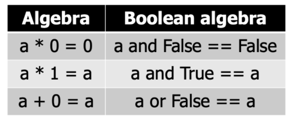

- `&&` has properties similar to multiplication
- `||` has properties similar to addition
- 0 and 1 correspond to false and true, respectively.
1. Anything `and`ed with false is false :
   - (a && false) == false
- 1b. Anything `and`ed with true is Anything:
  - (a && true) == a
1. Anything `or`ed with true is true :
   - (a || true) == true
- 2b. Anything `or`ed with false is Anything :
  - (a || false) == a

**Both 1 and 2 can be used in Short circuit evaluation**

**Short circuit evaluation** is the concept of skipping the evaluation of the second part of a boolean expression in a conditional statement when the entire statement has already been determined to be either true or false

1. Both `and` and `or` distribute: (FYI)
   - a || (b && c) == (a || b) && (a || c)
   - a && (b || c) == (a && b) || (a && c)
2. Double negatives cancel out:
   - !(! a) == a
3. **DeMorgan’s laws**: (EVERYBODY should KNOW)
   - !(a || b) == (! a) && (! b)
   - !(a && b) == (! a) || (! b)

```c
6 <=10 && true
```

```
True
```

```c
!(7 > 10 && 8 < 10)
```

```
True
```

```c
//Boolean Algebra
//Anything `AND' with false is false
(5 > 10 && 8 != 9 || 6 <= 10) && false
```

```
False
```

```c
//Double negatives cancel out
! (! (6 <= 10)) // is equivalent to 6 <=10,
```

```
True
```

```c
//!(7 > 10 && 8 < 10)   apply DeMorgan's Law
//step1: !(7 > 10) || !(8 < 10)
!(7 > 10) || !(8 < 10)
```

```
True
```

```c
//!(7 > 10 && 8 < 10)
//step1: apply DeMorgan's Law  !(7 > 10) || !(8 < 10)
//step2: opposite the relational operators
7 <= 10 || 8 >= 10
```

```
True
```

```c
6 <= 10
```

```
True
```

```c
//apply DeMorgan's Law
!(! 6 <= 10)  // !(6 > 10) -> 6 <= 10
```

[output not shown]

```c
! (7 < 10) || true     //is equivalent to ! (7 < 10) or true
```

```
True
```

```c
! (7 < 10 || true) // this is different, note the parenthesis
```

```
False
```

```c
!(7 < 10) && !true
```

```
False
```

```c
//In-class excercise Boolean Algebra
#include <stdio.h>
#include <stdbool.h>

int main(){

    printf("Boolean Algebra\n");
    printf("6 <=10 && true :%s\n", 6 <=10 && true ? "true": "false");

    printf("(5 > 10 && 8 != 9 || 6 <= 10) && false :  %s\n",(5 > 10 && 8 != 9 || 6 <= 10) && false  ? "true": "false");
    printf("\nshort circuit:\n");
    printf("(7 < 3) && (5 > 10 && 8 != 9 || 6 <= 10)  :  %s\n",(7 < 3) && (5 > 10 && 8 != 9 || 6 <= 10)   ? "true": "false");
    printf("  false AND anything is false; omitting evaluating anything\n");
    printf("(7 > 3) || (5 > 10 && 8 != 9 || 6 <= 10)  :  %s\n",(7 > 3) || (5 > 10 && 8 != 9 || 6 <= 10)   ? "true": "false");
     printf("  true OR anything is true; omitting evaluating anything\n\n");

    printf("! (7 < 10) || true :  %s\n",! (7 < 10) || true   ? "true": "false");

    printf("! (7 < 10 || true ):  %s\n", ! (7 < 10 || true) ? "true": "false"); //false

    printf("De Morgan's law\n");
    printf("!(7 < 10) && !true: %s\n", !(7 < 10) && !true ? "true": "false"); //false

    printf("!(7 > 10 && 8 < 10):  %s\n", !(7 > 10 && 8 < 10)  ? "true": "false");
    printf("!(7 > 10) || !(8 < 10):  %s\n", !(7 > 10) || !(8 < 10) ? "true": "false");
    printf("7 <= 10 || 8 >= 10:  %s\n", 7 <= 10 || 8 >= 10 ? "true": "false");


    return 0;
}
```

```
Boolean Algebra
6 <=10 && true :true
(5 > 10 && 8 != 9 || 6 <= 10) && false :  false

short circuit:
(7 < 3) && (5 > 10 && 8 != 9 || 6 <= 10)  :  false
  false AND anything is false; omitting evaluating anything
(7 > 3) || (5 > 10 && 8 != 9 || 6 <= 10)  :  true
  true OR anything is true; omitting evaluating anything

! (7 < 10) || true :  true
! (7 < 10 || true ):  false
De Morgan's law
!(7 < 10) && !true: false
!(7 > 10 && 8 < 10):  true
!(7 > 10) || !(8 < 10):  true
7 <= 10 || 8 >= 10:  true
```

## Examples

#### apply deMorgan's law

`! (16 > 14 && 8 >= 6)`

- step1: `! (16 > 14) || ! (8>=6)`
- step2: `16 <=14 || 8 <6`

#### apply deMorgan's law

`!(x > 23 || y == 9)`

- step1: `!(x > 23) && !(y == 9)`
- step2: `x <= 23 && y != 9`

#### apply deMorgan's law

`!(x != 10 && y >= 44)`

- step1: `!(x != 10) || !(y>=44)`
- step2: `x == 10 || y < 44`

#### apply deMorgan's law

`!(x > 18 && y <= 21 || z != 15)`

- step1: `!((x > 18 && y <= 21) || z != 15)`add parenthesis to make it as two exps
- step2: `(!(x > 18 and y <= 21)) && !( z != 15)` apply deMorgan's law, note the parenthesis
- step3: `(!(x > 18) || !( y <= 21)) && !( z != 15)` apply deMorgan's law for the parenthesis part, keep the parenthesis
- step3: `(x <= 18 || y > 21) && z == 15` remove `not`, keep the parenthesis

back to top

6. Switch-case

### Example 6-1

Write code to display "Great", "Good", "Average", "Bad", "Terrible" and "Confused" if the grade is 'A','B','C','D','F', and something else.

```c
#include <stdio.h>
int main(){
    char grade = 'B';
    if (grade == 'A')
        printf("Great");
    else if (grade == 'B')
        printf("Good");
    else if (grade == 'C')
        printf("Average");
    else if (grade == 'D')
        printf("Bad");
    else if (grade == 'F')
        printf("Terrible");
    else
        printf("Confused");

    return 0;
}
```

[output not shown]

- [zb_3.11](https://learn.zybooks.com/zybook/COFCCSCI218XuFall2022/chapter/3/section/11)
- A **switch** statement can more clearly represent multi-branch behavior involving a variable being compared to **constant values**.
- The program executes the first `case` whose constant expression matches the value of the switch expression, executes that case's statements, and then jumps to the end.
- If no case matches, then the `default` case statements are executed.

```c
#include <stdio.h>
int main(){
    char grade = 'c';
    switch(grade){
    case 'A':
      printf("Great");
      break;
    case 'B':
      printf("Good");
      break;
    case 'C':
      printf("Average");
      break;
    case 'D':
      printf("Bad");
      break;
    case 'F':
      printf("Terrible");
      break;
    default:
      printf("Confused");
      break;
    }
    return 0;
  }
```

```
Confused
```

6.1 Omitting the break statement

- Omitting the break statement for a case will cause the statements within the next case to be executed. Such "falling through" to the next case can be useful when multiple cases, such as cases 'A', 'B' , should execute the same statements.

```c
#include <stdio.h>
int main(){
    char grade = 'A';
    switch(grade){
    case 'A':
    case 'B':
      printf("Good");
      break;
    case 'C':
    case 'D':
      printf("PASS");
      break;
    case 'F':
      printf("See you next semester");
      break;
    default:
      printf("Confused");
      break;
    }
    return 0;
  }
```

```
Good
```

6.2 (FYI) The Ellipsis Operator ( ... ) in Arduino C

The Ellipsis Operator ( ... ) in Arduino C (it is NOT a part of Standard C) Sometimes, if we want assign grades such that 0 to 59 is an F, 60 to 69 is a D, 70 to 79 is a C, and so on . In this situation, we can use the ellipsis operator.

```c
char letterGrade;
    int grade = 72;
    // some code that gives grade a value between 0 and 100
    switch (grade) {
        case 0...59:
            letterGrade = 'F';
            break;
        case 60...69:
            letterGrade = 'D';
            break;
        case 70...79:
            letterGrade = 'C';
            break;
        case 80...89:
            letterGrade = 'B';
            break;
        case 90...100:
            letterGrade = 'A';
            break;
        default:
            Serial.println("Should never see this.");
            break;
    }
```

back to top

7. C Standard library

The C Standard Library is a set of C built-in functions, constants and header files like <stdio.h>, <stdlib.h>, <math.h>, etc.

### [<math.h>](https://www.tutorialspoint.com/c_standard_library/math_h.htm)

- see [zybook2.10](https://learn.zybooks.com/zybook/COFCCSCI218XuFall2023/chapter/2/section/10)
- The math.h header defines various mathematical functions and one macro.
- All the functions available in this library take double as an argument and return double as the result.
- To use those mathematical functions, the `#include <math.h>` statement has to be placed at the top of your program
- Example: use sqrt(), pow() and log10() defined in math.h

```c
//Example 7-1:
#include <stdio.h>
#include <math.h>
int main(){
    int x;
    x = 4;
    float y;
    y = sqrt(x);
    printf("x= %d, sqrt(x) = %f\n", x, y);
    y = pow(x, 2);
    printf("x= %d, x^2 = %f\n", x, y);
    x = 100;
    y = log10(x);
    printf("x= %d, log10(x) = %f\n", x, y);
    x = 64;
    y = log2(x);
    printf("x= %d, log2(x) = %d\n", x, (int)y);
    return 0;
}
```

```
x= 4, sqrt(x) = 2.000000
x= 4, x^2 = 16.000000
x= 100, log10(x) = 2.000000
x= 64, log2(x) = 6
```